# Chapter 4 - The grammar of graphics and the `ggplot2` package

Edson Raul Cepeda Marquez

The *ggplot* package provides an alternative to the basic graphics that is based on what is called the “grammar of graphics”. **The idea here is that the system gives you small domain-specific language for creating plots**. You construct plots through a list of function calls. *This functions calls do not directly write on a canvas independedntly of each other*. **They manipulate a plot by either modifying it or adding layers of visualization to the plot**.

```r
library(ggplot2)
library(magrittr)
library(tidyr)
library(dplyr)
library(knitr)
# library(help = "ggplot2")
```

### Using qplot()

The `qplot()` function can be used to plot simple scatterplots the same way as the `plot()` function.

```r
cars %>% qplot(speed, dist, data = .)
```

The `qplot()` creates a `ggplot` object rather than directly plotting. THe previous is equivalent to this:

```r
p <- cars %>% qplot(speed, dist, data = .)
p
```

**It is not recommended to use `qplot`, it is done here, to show the functionality**. With `qplot()`, you can make the visualization of data points depend on data variables in a simpler way. With `qplot()`, you just specify that you want the color to depend on the Species variable:

```r
iris %>% qplot(Petal.Width, Petal.Length, color = Species, data = .)
```

You can use `qplot()` for other types of plots other than scatterplots. If you give it a single variable to plot, it will assume that you want a histogram instead of a scatterplot.

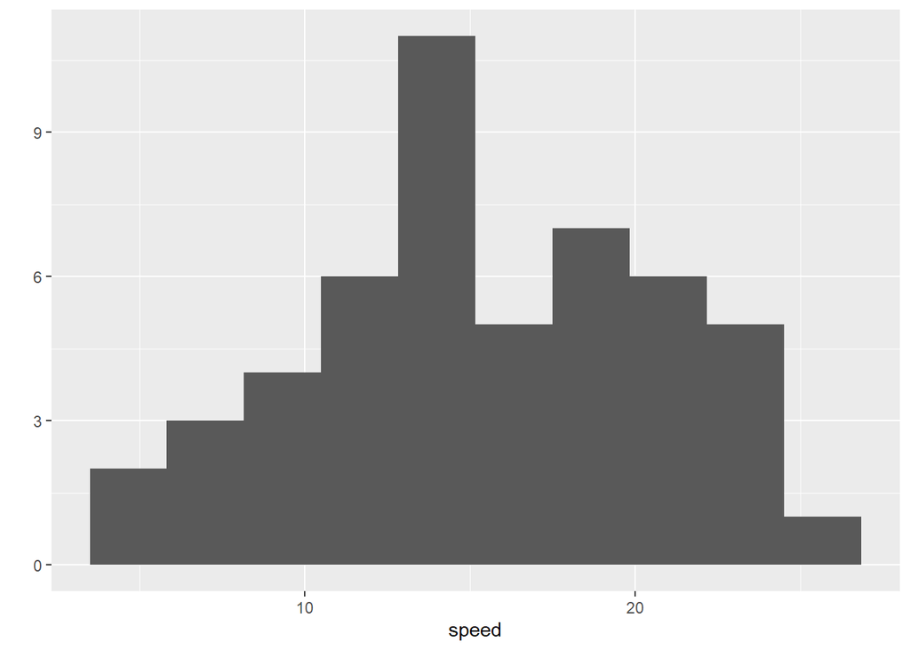

```r
cars %>% qplot(speed, data = ., bins = 10)
```

If you want a density plot instead:

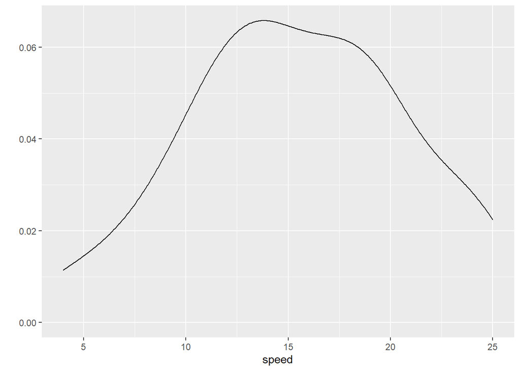

```r
cars %>% qplot(speed, data = ., geom = "density")
```

### Using Geometries

To create this plot using explicit geometries we want a `ggplot` object, we need to map the *speed* parameter from the data frame to the x-axis and the *dist* parameter to the y-axis, and we need to plot the data as points.

The procedure is as follows (Different data mapping to different geometries): - We create a `ggplot` object and we give *cars* (data frame) as input. - We specify that we want this to be plotted as points with `geom_points()`. - Finally we use the `aes()` function inside `geom_points()` to map the data as the `geom_point()` function needs a x and y value. The `aes()` function is responsible for mapping the data to graphics.

```r
ggplot(cars) + geom_point(aes(x = speed, y = dist))
```

When we want to share aesthetics between functions, we cn set it in the `ggplot()` function. Then the next functions can acces to the data and we don’t have to specify it for each subsequent function.

```r
ggplot(cars, aes(x = speed, y = dist)) + geom_point()
```

You use **+** to string together a series of commands to modify a `ggplot` object.

A typical pattern is to first modify data in a string of %>% operations and then give it to `ggplot()` and follow that with a series of + operations.

```r
cars %>% ggplot(aes(x = speed, y = dist)) + geom_point()
```

For the *iris* data we used `qplot()` call to create a scatter plot with colors determined by the *Species* variable.

```r
iris %>% qplot(Petal.Width, Petal.Length, color = Species, data = .)
```

The corresponding code using `ggplot()`and `geom_points()` looks like this:

```r
iris %>% ggplot + geom_point(aes(x = Petal.Width, y = Petal.Length, color = Species))
```

```r
# ggplot(iris) + geom_point(aes(x = Petal.Width, y = Petal.Length, color=Species))
```

If you instead want to hard-wire the color, or any graphics parameter in general, you simply have to move the parameter assignment outside the `aes()` call.

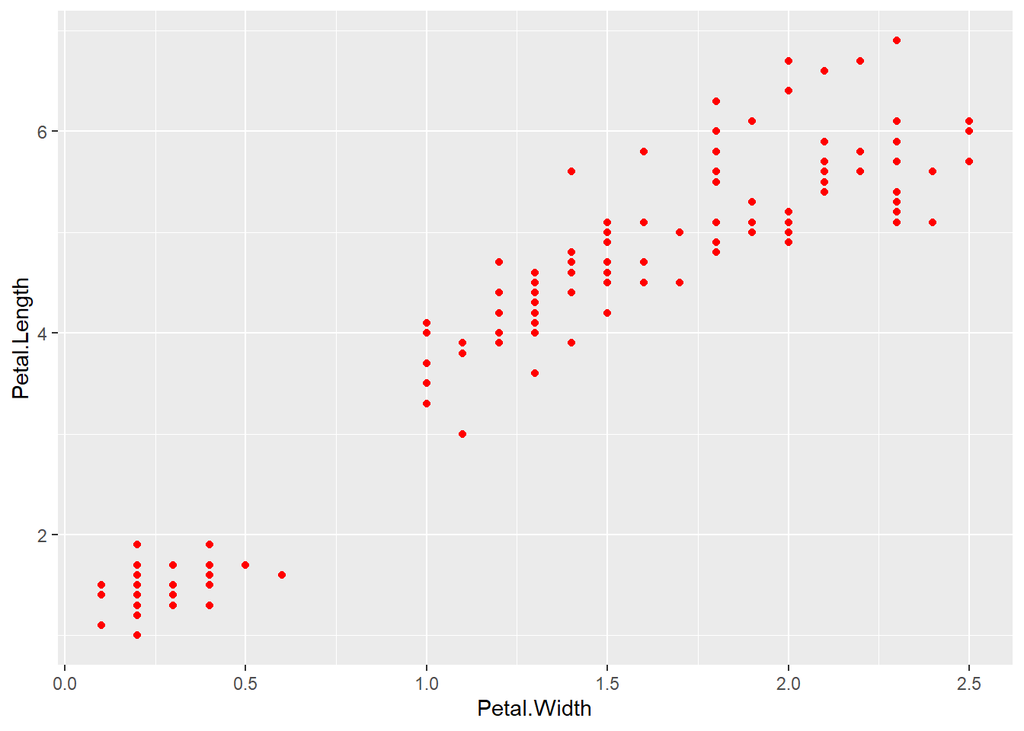

```r
iris %>% ggplot + geom_point(aes(x = Petal.Width, y = Petal.Length), color = "red")
```

The `qplot()` code for plotting the histogram and a density plot:

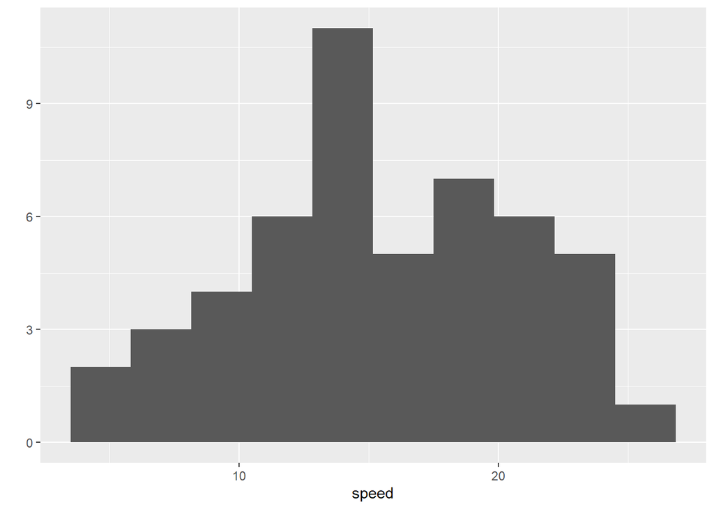

```r
cars %>% qplot(speed, data = ., bins = 10)
```

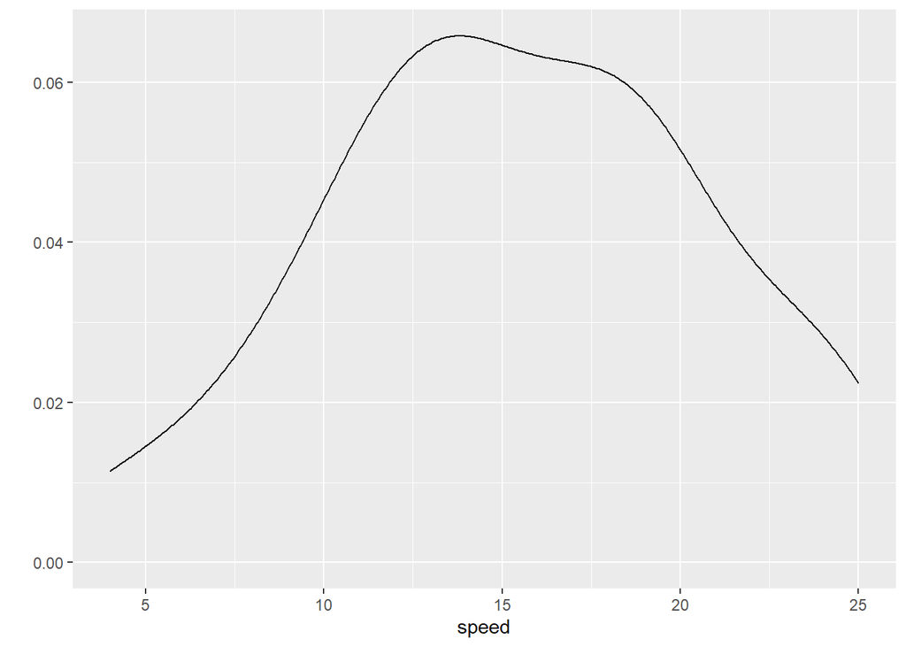

```r
cars %>% qplot(speed, data = ., geom = "density")
```

Can be constructed using `geom_histogram()` and `geom_density()`:

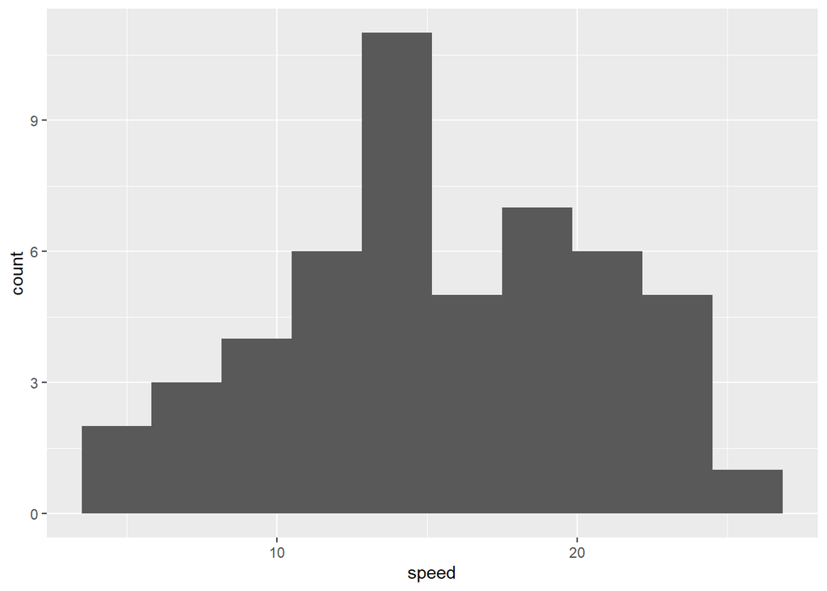

```r
cars %>% ggplot + geom_histogram(aes(x = speed), bins = 10)
```

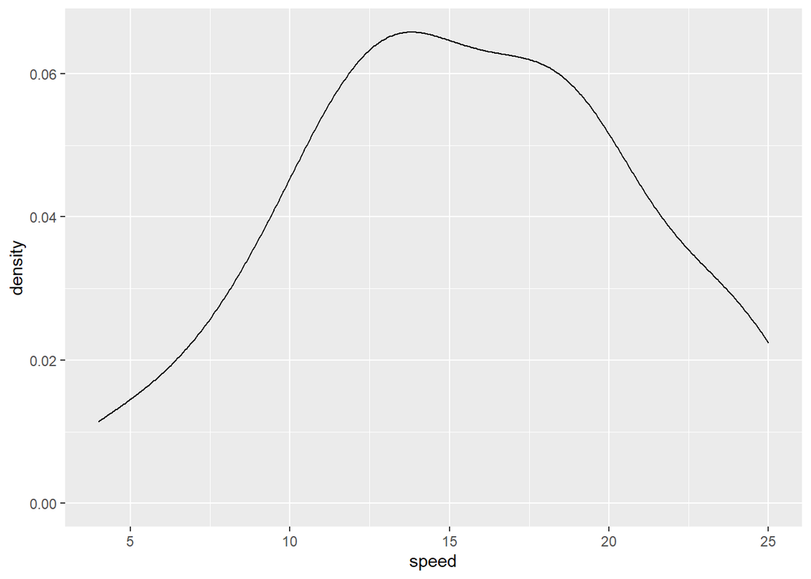

```r
cars %>% ggplot + geom_density(aes(x = speed))
```

You can combine more geometries to display the data in more than one way.

You do also need to add an extra aesthethics option for the y value. This is because histograms by default will show the counts of how many observationss gall within a bin on the y-axis, while densities integrate to one.

By setting y = ..count.., you tell both geometries to use counts as the y-axis. To get densities instead, you can use y = ..density…

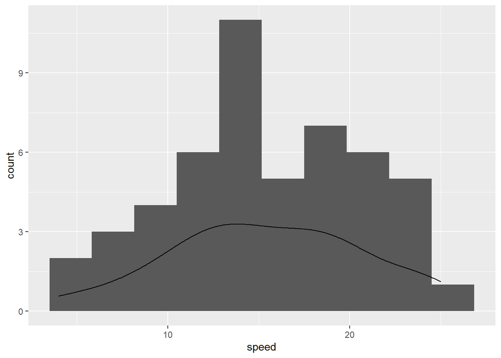

```r
cars %>% ggplot(aes(x = speed, y = ..count..)) +
    geom_histogram(bins = 10) +
    geom_density()
```